# STA 380 Homework 1

## Market Segment Problem

Summary of Social Marketing Data

```
##          X           chatter       current_events      travel
##  123pxkyqj:   1   Min.   : 0.000   Min.   :0.000   Min.   : 0.000
##  12grikctu:   1   1st Qu.: 2.000   1st Qu.:1.000   1st Qu.: 0.000
##  12klxic7j:   1   Median : 3.000   Median :1.000   Median : 1.000
##  12t4msroj:   1   Mean   : 4.399   Mean   :1.526   Mean   : 1.585
##  12yam59l3:   1   3rd Qu.: 6.000   3rd Qu.:2.000   3rd Qu.: 2.000
##  132y8f6aj:   1   Max.   :26.000   Max.   :8.000   Max.   :26.000
##  (Other)  :7876
##  photo_sharing    uncategorized      tv_film      sports_fandom
##  Min.   : 0.000   Min.   :0.000   Min.   : 0.00   Min.   : 0.000
##  1st Qu.: 1.000   1st Qu.:0.000   1st Qu.: 0.00   1st Qu.: 0.000
##  Median : 2.000   Median :1.000   Median : 1.00   Median : 1.000
##  Mean   : 2.697   Mean   :0.813   Mean   : 1.07   Mean   : 1.594
##  3rd Qu.: 4.000   3rd Qu.:1.000   3rd Qu.: 1.00   3rd Qu.: 2.000
##  Max.   :21.000   Max.   :9.000   Max.   :17.00   Max.   :20.000
##
##     politics           food            family        home_and_garden
##  Min.   : 0.000   Min.   : 0.000   Min.   : 0.0000   Min.   :0.0000
##  1st Qu.: 0.000   1st Qu.: 0.000   1st Qu.: 0.0000   1st Qu.:0.0000
##  Median : 1.000   Median : 1.000   Median : 1.0000   Median :0.0000
##  Mean   : 1.789   Mean   : 1.397   Mean   : 0.8639   Mean   :0.5207
##  3rd Qu.: 2.000   3rd Qu.: 2.000   3rd Qu.: 1.0000   3rd Qu.:1.0000
##  Max.   :37.000   Max.   :16.000   Max.   :10.0000   Max.   :5.0000
##
##      music              news        online_gaming       shopping
##  Min.   : 0.0000   Min.   : 0.000   Min.   : 0.000   Min.   : 0.000
##  1st Qu.: 0.0000   1st Qu.: 0.000   1st Qu.: 0.000   1st Qu.: 0.000
##  Median : 0.0000   Median : 0.000   Median : 0.000   Median : 1.000
##  Mean   : 0.6793   Mean   : 1.206   Mean   : 1.209   Mean   : 1.389
##  3rd Qu.: 1.0000   3rd Qu.: 1.000   3rd Qu.: 1.000   3rd Qu.: 2.000
##  Max.   :13.0000   Max.   :20.000   Max.   :27.000   Max.   :12.000
##
##  health_nutrition  college_uni     sports_playing      cooking
##  Min.   : 0.000   Min.   : 0.000   Min.   :0.0000   Min.   : 0.000
##  1st Qu.: 0.000   1st Qu.: 0.000   1st Qu.:0.0000   1st Qu.: 0.000
##  Median : 1.000   Median : 1.000   Median :0.0000   Median : 1.000
##  Mean   : 2.567   Mean   : 1.549   Mean   :0.6392   Mean   : 1.998
##  3rd Qu.: 3.000   3rd Qu.: 2.000   3rd Qu.:1.0000   3rd Qu.: 2.000
##  Max.   :41.000   Max.   :30.000   Max.   :8.0000   Max.   :33.000
##
```

[output cut: 25 more lines]

```
##  Min.   : 0.000   Min.   : 0.0000   Min.   :0.0000   Min.   :0.00000
##  1st Qu.: 0.000   1st Qu.: 0.0000   1st Qu.:0.0000   1st Qu.:0.00000
##  Median : 0.000   Median : 0.0000   Median :0.0000   Median :0.00000
##  Mean   : 1.462   Mean   : 0.9966   Mean   :0.3363   Mean   :0.00647
##  3rd Qu.: 2.000   3rd Qu.: 1.0000   3rd Qu.:1.0000   3rd Qu.:0.00000
##  Max.   :19.000   Max.   :18.0000   Max.   :6.0000   Max.   :2.00000
##
##      adult
##  Min.   : 0.0000
##  1st Qu.: 0.0000
##  Median : 0.0000
##  Mean   : 0.4033
##  3rd Qu.: 0.0000
##  Max.   :26.0000
##
```

Comments: chatter and uncategorized are similar so get rid of one of them- I got rid of uncategorized.I also go rid of spam and adult and ID for easier analysis.

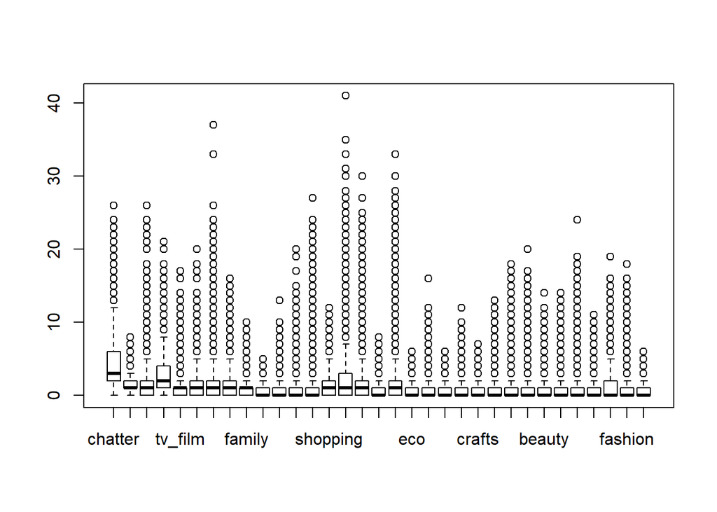

Comments: In this we see the various anamolies for each variable– interesting: all the outliers are only positive ones

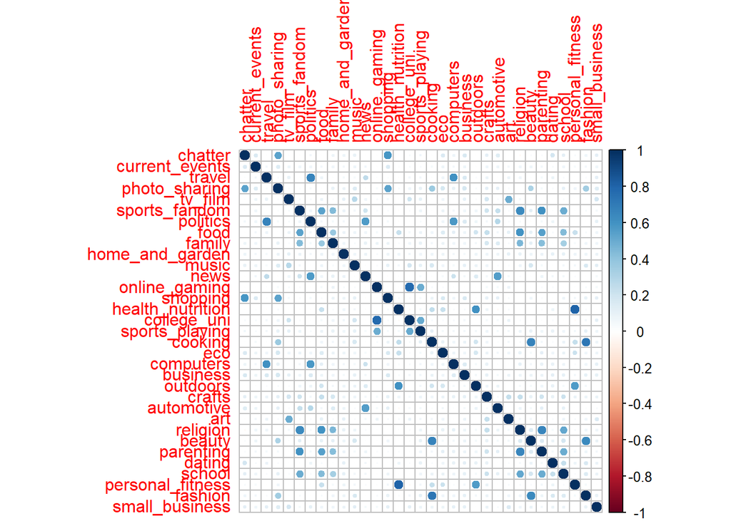

#### K-Means Approach

```
##  [1] 260073.0 237751.5 223180.2 211701.0 201103.6 191040.8 182562.4
##  [8] 175932.7 169484.3 164759.1 161424.9 158250.9 156005.2 153949.1
## [15] 152118.0 150273.2 149104.0 147698.5 146458.0 145104.2
```

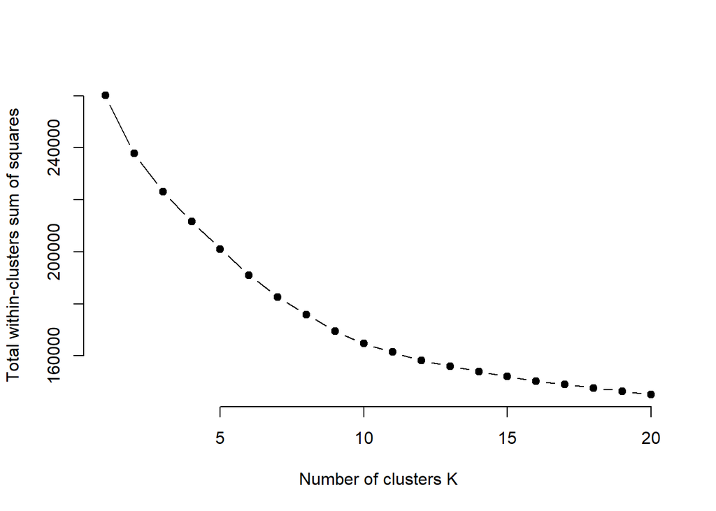

Comments: Started the k-means algorithm– plot shows the minimization of the sum of squares for the various number of clusters up to the max of 20. Looks like 10 is the best cluster size.

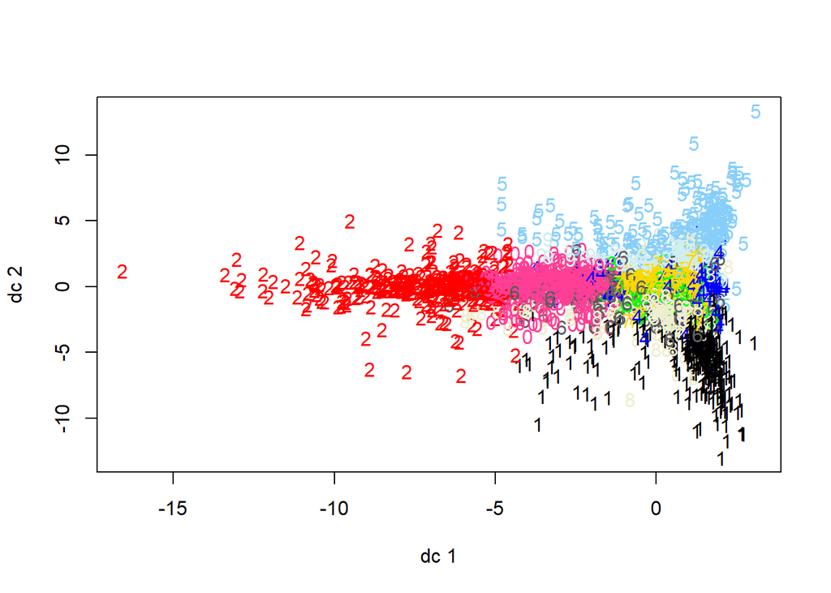

Comments: This graph plots the various clusters created and is displayed by the cluster number they are in. It looks relatively split and grouped well.

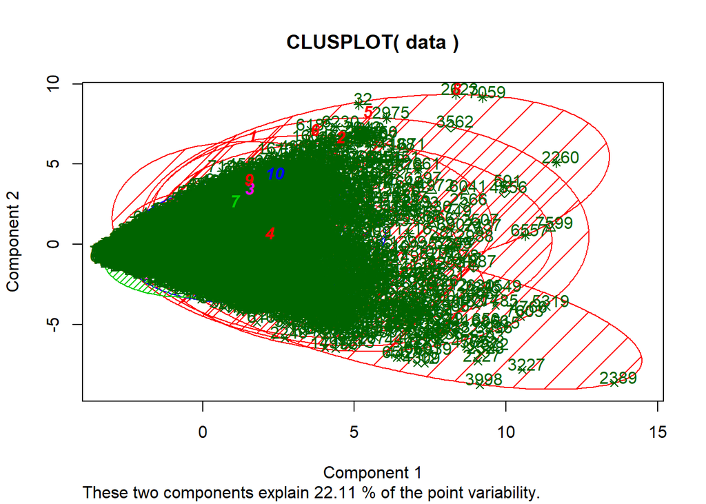

Comments: Gross and messy graph- probably not usable or interpretable

```
## List of 9
##  $ cluster     : int [1:7882] 2 7 3 7 3 3 5 8 2 4 ...
##  $ centers     : num [1:10, 1:33] 4.05 4.6 7.2 3.51 4.15 ...
##   ..- attr(*, "dimnames")=List of 2
##   .. ..$ : chr [1:10] "1" "2" "3" "4" ...
##   .. ..$ : chr [1:33] "chatter" "current_events" "travel" "photo_sharing" ...
##  $ totss       : num 1076310
##  $ withinss    : num [1:10] 44367 44314 64701 51718 42045 ...
##  $ tot.withinss: num 535087
##  $ betweenss   : num 541223
##  $ size        : int [1:10] 386 363 1269 574 344 489 2724 473 407 853
##  $ iter        : int 6
##  $ ifault      : int 0
##  - attr(*, "class")= chr "kmeans"
```

Comments: Here is the summary of the clusters created. We can see the sizes and other attributes.

Top 3 Categories for Cluster 1

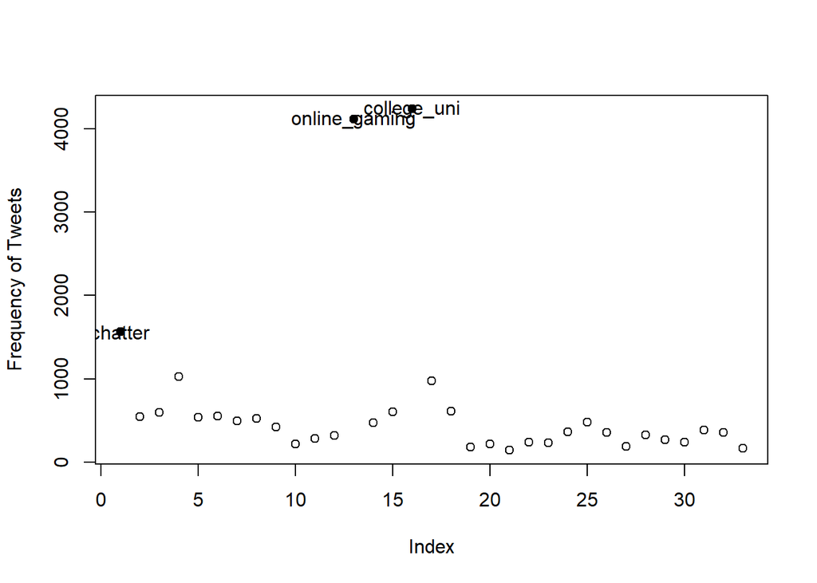

Top 3 Categories for Cluster 2

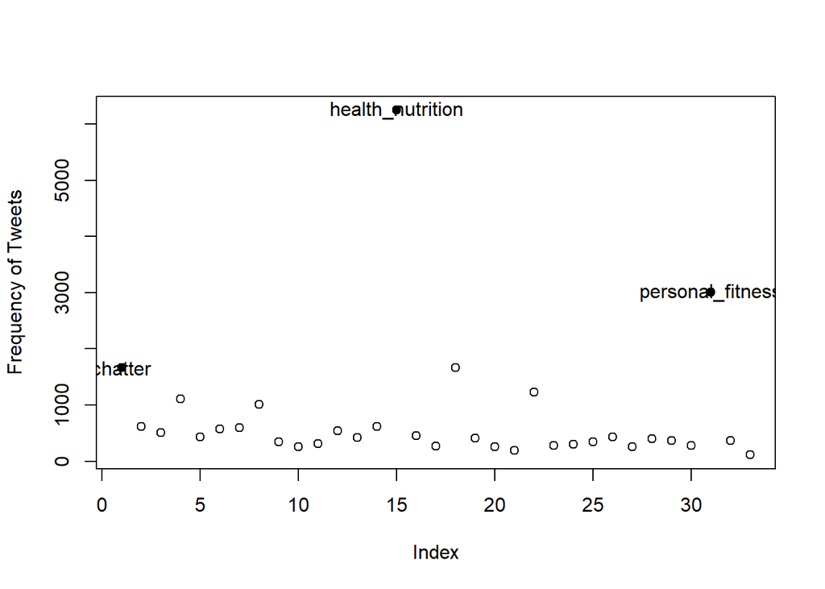

Top 3 Categories for Cluster 3

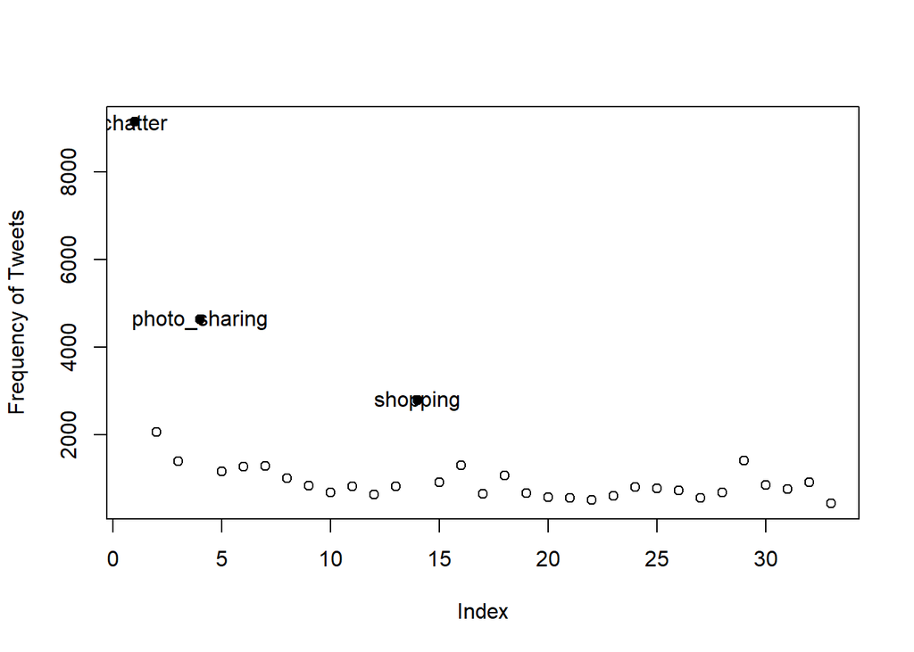

Top 3 Categories for Cluster 4

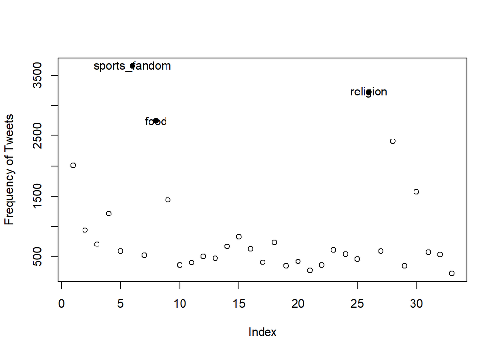

Top 3 Categories for Cluster 5

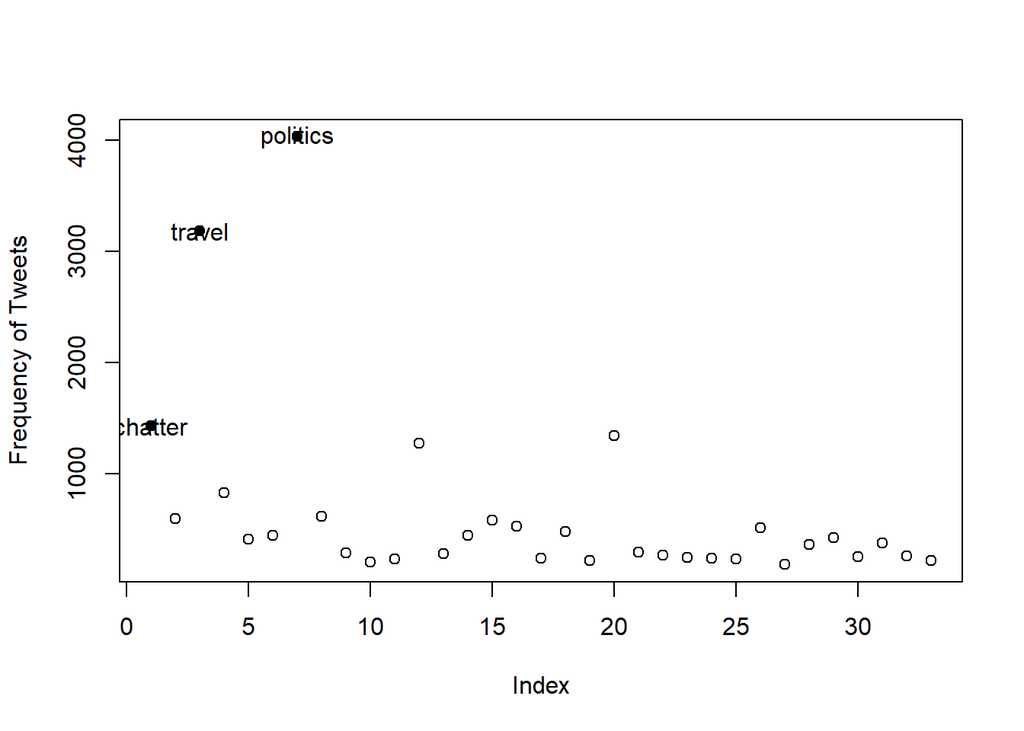

Top 3 Categories for Cluster 6

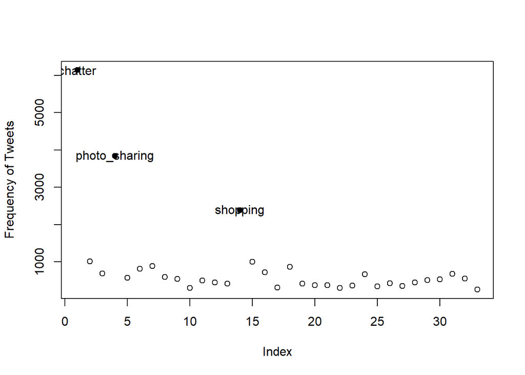

Top 3 Categories for Cluster 7

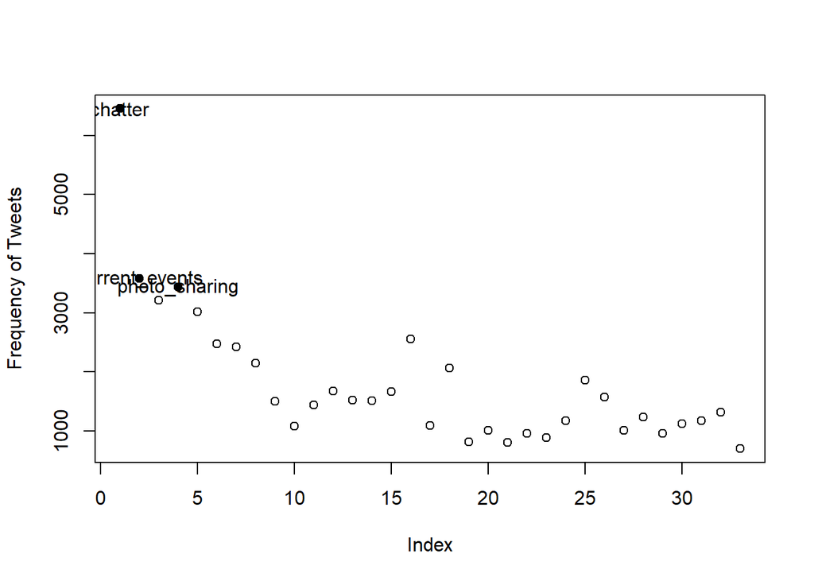

Top 3 Categories for Cluster 8

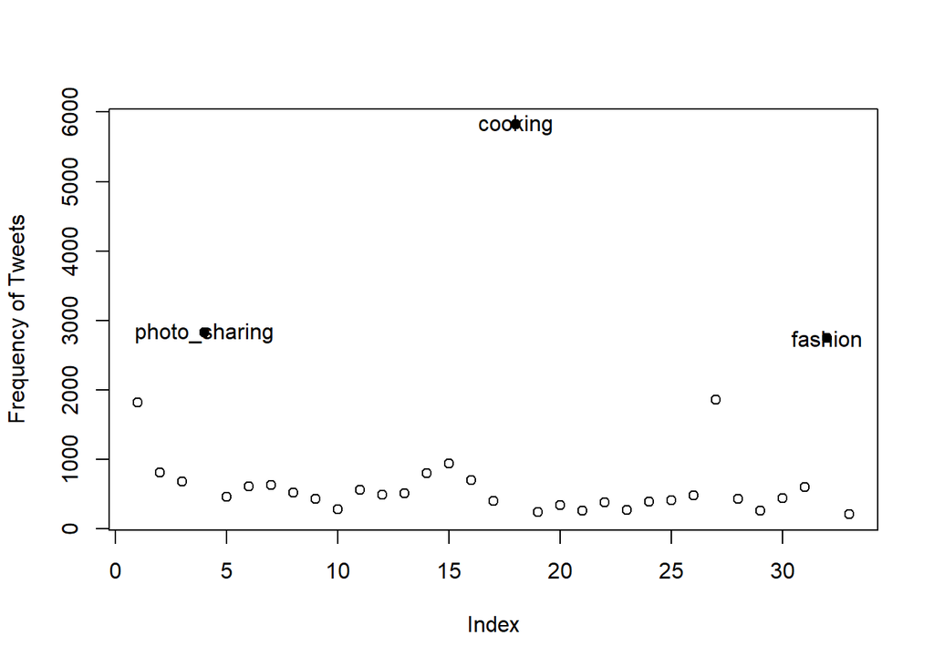

Top 3 Categories for Cluster 9

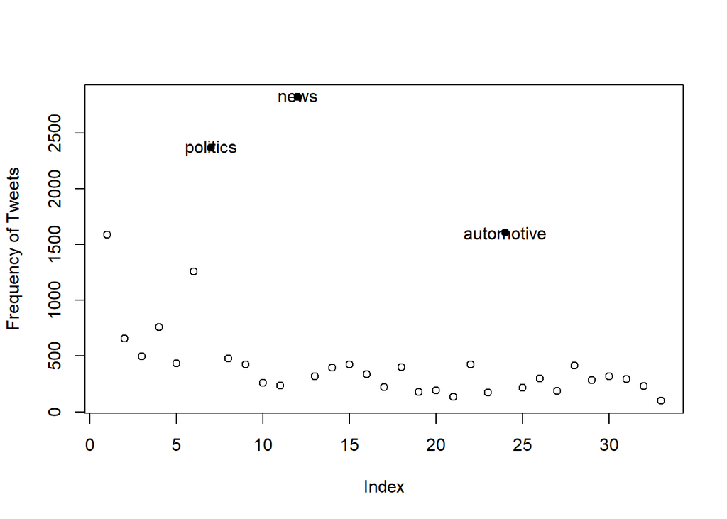

Top 3 Categories for Cluster 10

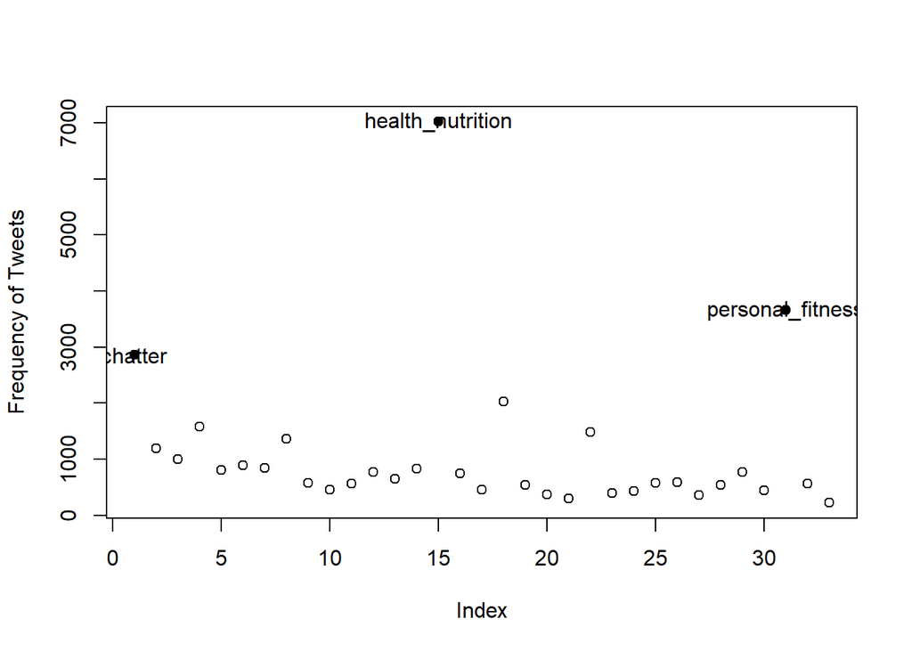

Other methods tried:

#### PCA

```
## Importance of components:
##                          PC1     PC2     PC3     PC4     PC5     PC6
## Standard deviation     2.111 1.68580 1.59326 1.53403 1.47848 1.36826
## Proportion of Variance 0.135 0.08612 0.07692 0.07131 0.06624 0.05673
## Cumulative Proportion  0.135 0.22112 0.29804 0.36935 0.43559 0.49233
##                            PC7     PC8     PC9   PC10   PC11    PC12
## Standard deviation     1.27409 1.19215 1.06092 0.9934 0.9681 0.96181
## Proportion of Variance 0.04919 0.04307 0.03411 0.0299 0.0284 0.02803
## Cumulative Proportion  0.54152 0.58458 0.61869 0.6486 0.6770 0.70503
##                           PC13    PC14    PC15    PC16    PC17    PC18
## Standard deviation     0.93984 0.92317 0.91605 0.85455 0.80890 0.75383
## Proportion of Variance 0.02677 0.02583 0.02543 0.02213 0.01983 0.01722
## Cumulative Proportion  0.73180 0.75762 0.78305 0.80518 0.82501 0.84223
##                           PC19    PC20    PC21    PC22   PC23   PC24
## Standard deviation     0.69805 0.68770 0.65471 0.65041 0.6398 0.6372
## Proportion of Variance 0.01477 0.01433 0.01299 0.01282 0.0124 0.0123
## Cumulative Proportion  0.85699 0.87133 0.88432 0.89713 0.9095 0.9218
##                           PC25    PC26    PC27    PC28    PC29    PC30
## Standard deviation     0.61729 0.60206 0.59482 0.58767 0.55066 0.48580
## Proportion of Variance 0.01155 0.01098 0.01072 0.01047 0.00919 0.00715
## Cumulative Proportion  0.93339 0.94437 0.95509 0.96556 0.97475 0.98190
##                           PC31    PC32   PC33
## Standard deviation     0.47616 0.43858 0.4222
## Proportion of Variance 0.00687 0.00583 0.0054
## Cumulative Proportion  0.98877 0.99460 1.0000
```

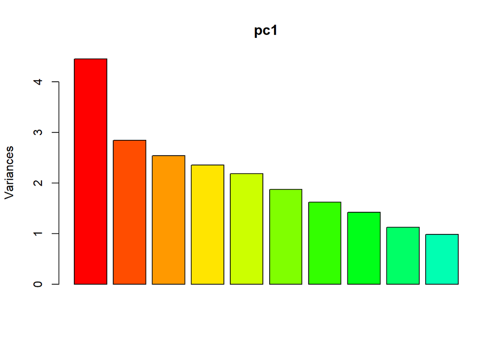

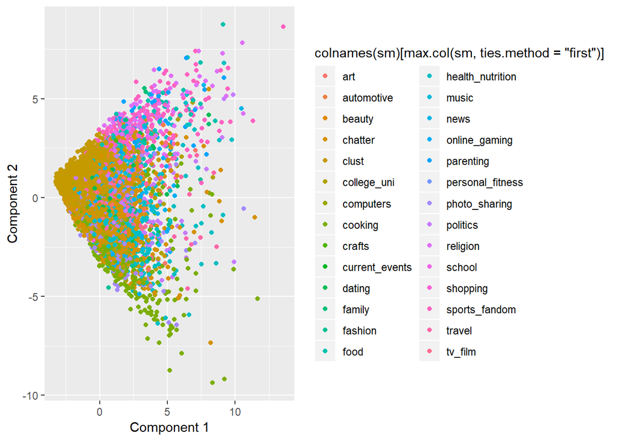

Comments: Here we see the PC1 vs PC2 plot. The points are colored by the corresponding category it is in. We can see that green and orange points are more towards the left negative and purple and blue more towards the right positive.

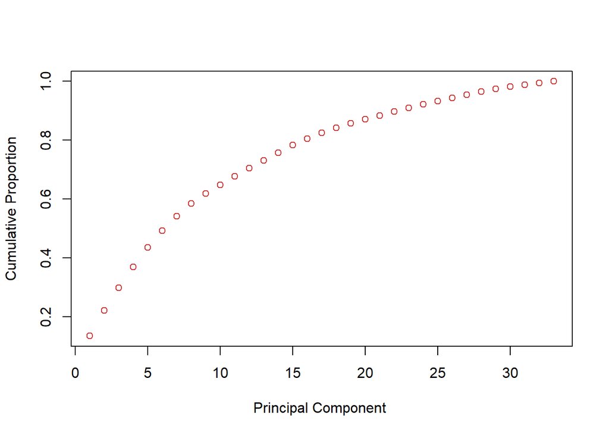

Comments: This graph shhows the cumulative proportion against the PC– it looks like between 15 and 20 would be the ideal number of components.

#### Hierarchical Clustering

```
##    1    2    3    4    5    6    7    8    9   10
##  299 5409  785  295  540  107  340   68   31    8
```

Comments: The summary shows the sizes of the different clusters– I don’t like it that much due to how different the sizes are.

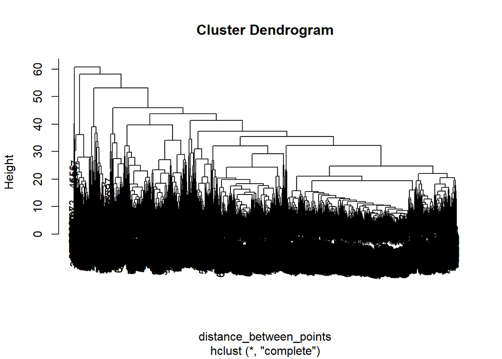

Comments: plot of the dendrogram

## Report

In my analysis, I found k-means to be the most appropriate and usable given my knowledge. I split the data into 10 clusters– in the voice of the business, these would be the 10 market segments. I only plotted the top 3 max frequencies of tweets for each category, but ideally we would do a little more cleaning and retrieve the medians of each category for frequency. This would then show us how each category would be different. But using the analysis I found, we would market towards the higher frequency categories based on the clusters. I found many had chatter as a top contender so it seems that it would be helpful to create more categories to break down chatter even more.